# Estimating the conditional variance

By local linear regression

Wanchang Zhang

2023-03-14

Aircraft Data We are using the Aircraft Data from R library `sm`. These data record six characteristics of aircraft designs which appeared during the 20th century.

- `Yr` Year of first manufacture.
- `Period` a code to indicate one of three broad time periods
- `Power` total engine power (kW)
- `Span` wing span (m)
- `Weight` maximum take-off weight(kg)
- `Speed` maximum speed(km/h)
- `Range` range(km)

We transform data taken logs (except`Yr` and `Period`); to `lgPower`,`lgSpan`,`lgWeight`,`lgSpeed`,`lgRange`

```r
library(sm)
data(aircraft)
help(aircraft)
```

```
## starting httpd help server ...
```

```
##  done
```

```r
attach(aircraft)
lgPower <- log(Power)
lgSpan <- log(Span)
lgLength <- log(Length)
lgWeight <- log(Weight)
lgSpeed <- log(Speed)
lgRange <- log(Range)
```

# Estimatiing the conditional variance

Consider the heteroscedastic regression model
$$Y = m(x)+\sigma(x)\varepsilon =
m(x)+\epsilon$$
where $E(\varepsilon)=0,V(\varepsilon)=1$ and $\sigma^2(x)$ is an unknown function that gives the conditional variance of $Y$ given that the explanatory variable is equal to $x$. Let us define
$$Z = \log((Y-m(X))^2) = \log \varepsilon^2$$
and $\delta = \log(\epsilon^2)$ is a random variable with expected value close to 0 (observe that $E[\log\varepsilon^2])\approx \log E(\epsilon^2) = \log(V(\epsilon)) = \log(1) = 0$ ) taking the role of noise in the regression of $Z$ against $x$ (that is, $Z$ is the response variable and $x$ is the predicting variable) . Given that the values of $\epsilon_i^2$ are not observable, a way to estimate the function $\sigma^2(x)$ is as follows:

- 1 Fit a nonparameteric regression to data $(x_i,y_i)$ and save the estimated values $\hat{m}(x_i)$.

```r
source("R scripts for Local Plynomial Regression/lpr_visual.R")
source("R scripts for Local Plynomial Regression/locpolreg.R")
```

```r
h.cv.gcv <- function(x,y,h.v = exp(seq(log(diff(range(x))/20),
                                       log(diff(range(x))/4),l=10)),
                     p=1,type.kernel="normal"){
  n <- length(x)
  cv <- h.v*0
  gcv <- h.v*0
  for (i in (1:length(h.v))){
    h <- h.v[i]
    aux <- locpolreg(x=x,y=y,h=h,p=p,tg=x,
                     type.kernel=type.kernel, doing.plot=FALSE)
    S <- aux$S
    h.y <- aux$mtgr
    hii <- diag(S)
    av.hii <- mean(hii)
    cv[i] <- sum(((y-h.y)/(1-hii))^2)/n
    gcv[i] <- sum(((y-h.y)/(1-av.hii))^2)/n
  }
  return(list(h.v=h.v,cv=cv,gcv=gcv))
}
```

## k-Fold Cross-Validation

```r
k.fold.cv <- function(x,y,k=10,h=range(x)/10,p=1,type.kernel="normal"){
  n <- length(x)
  Ik <- floor((0:(n-1))/(n/k))+1
  ssr <- 0
  for (i in (1:k)){
    y.i <- y[Ik==i]
    aux <- locpolreg(x[Ik!=i],y[Ik!=i],h=h,p=p,tg=x[Ik==i],
                     type.kernel=type.kernel, doing.plot=FALSE)
    ssr <- ssr + sum((y.i-aux$mtgr)^2)
  }
  k.cv <- ssr/n
  return(k.cv)
}

h.k.fold.cv <- function(x,y,h.v = exp(seq(log(diff(range(x))/20),
                                          log(diff(range(x))/4),l=10)),
                        k=10,p=1,type.kernel="normal"){
  n <- length(x)
  perm <- sample(1:n)
  xperm <- x[perm]
  yperm <- y[perm]

  k.cv <- h.v*0
  for (i in (1:length(h.v))){
    h <- h.v[i]
    k.cv[i] <- k.fold.cv(x=xperm,y=yperm,k=k,h=h,p=p,
                         type.kernel=type.kernel)
  }
  return(list(k=k,h.v=h.v,k.cv=k.cv))
}
```

```r
h.v <-  exp( seq(from=log(.5), to = log(15), length=12))
n = dim(aircraft)[1]
out.n.cv <- h.k.fold.cv(x=Yr, y=lgWeight, h.v=h.v, k=n)# n-fold-CV is the leave one out cross validation
opt.h.cv <- h.v[c(which.min(out.n.cv$k.cv))] # 4.35468
```

```r
res0_1 <- locpolreg(x=Yr,y=lgSpeed,h=opt.h.cv,q=1,r=1,main=paste("r=1,q=1,h=",opt.h.cv),type.kernel="epan")
```

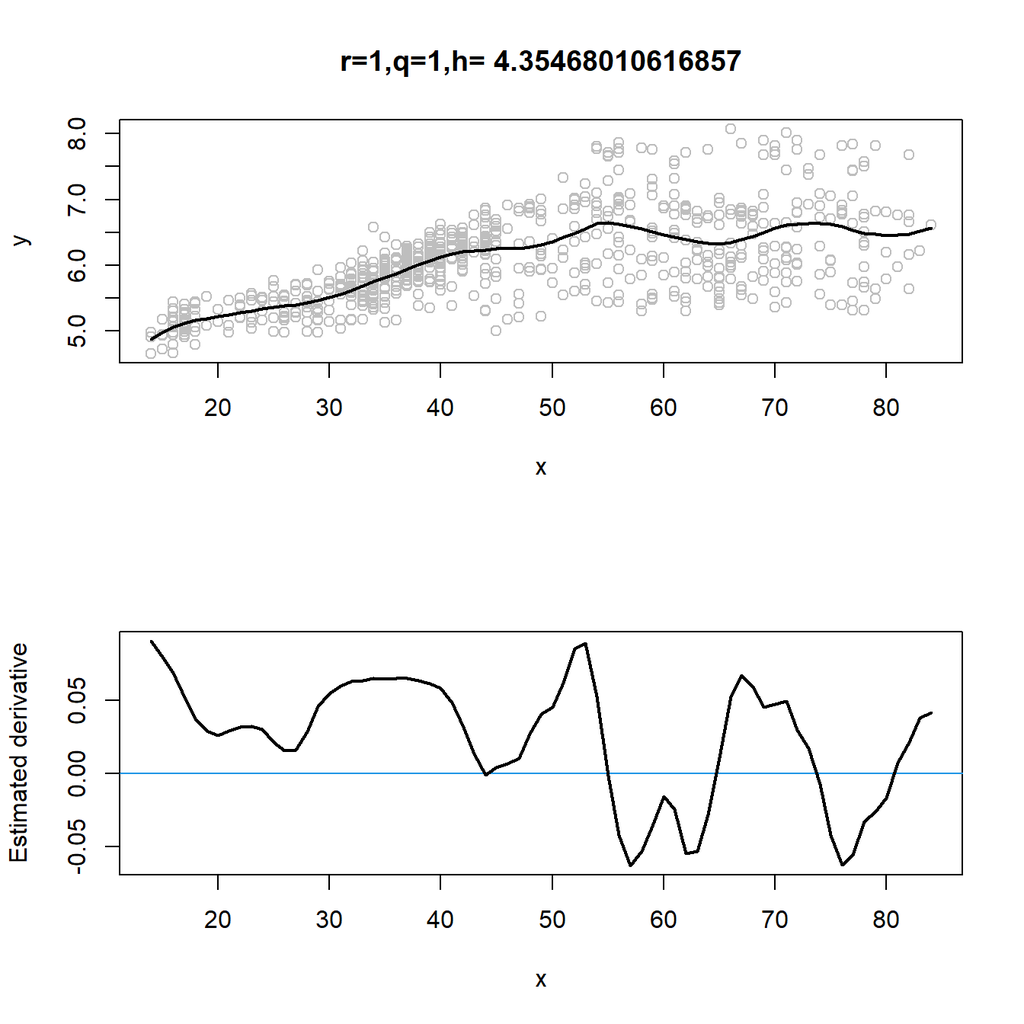

```r
res3_1 <- locpolreg(x=Yr,y=lgSpeed,h=opt.h.cv,q=3,r=1,main=paste("r=1,q=3,h=",opt.h.cv),type.kernel="epan")
```

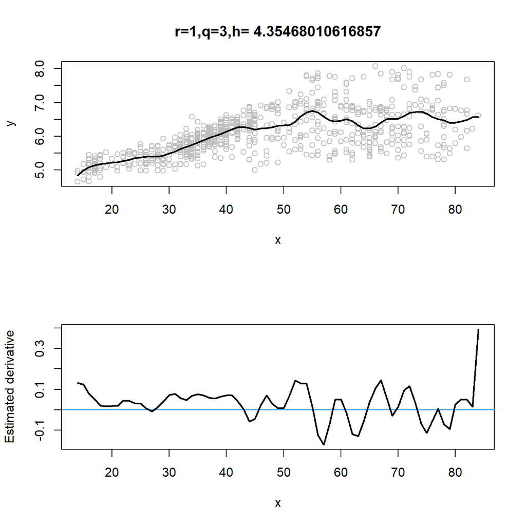

- 2 Transform the estimated residuals $\hat{\epsilon}_i = y_i-\hat{m}(x_i)$:
  $$z_i = \log \epsilon_i^2 =
  \log((y_i-\hat{m}(x_i))^2)$$

```r
epsilon = lgWeight - res0_1$mtgr
Z = log(epsilon^2)
```

- 3. Fit a nonparameteric regression to data $(x_i,z_i)$ and call the estimated function $\hat{q}(x)$. Observe that $\hat{q}(x)$ is an estimate of $\log(\sigma^2(x))$

Now fit Z against X again using a different method to choose the h and local polynomial regression

```r
require(KernSmooth) # for function "dpill"
(h.dpi <- dpill(x=Yr,y=Z,gridsize=101,range.x=range(Yr)))# h = 1.857887
```

```
## [1] 1.857887
```

```r
require(sm)
q = sm.regression(x=Yr,y=Z,h=h.dpi,pch=1,cex=1,lwd=2)
```

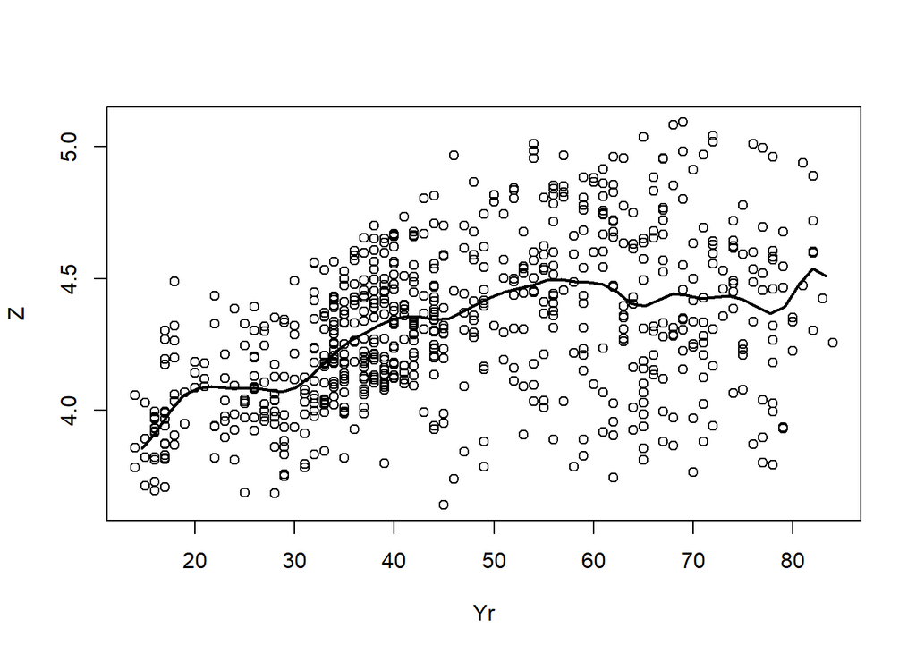

```r
res_check <- locpolreg(x=Yr,y=lgSpeed,h=h.dpi,q=1,r=1,main=paste("r=1,q=1,h=",opt.h.cv),type.kernel="epan")
```

[figure not shown]

* 4 Estimate $\sigma^2(x)$ by
$$\hat{\sigma}^2(x) = \exp{\hat{q}(x)}$$

```r
variance = exp(q$estimate) # length 50
variance.check = exp(res_check$mtgr)
```

```r
FinalY.upper = res0_1$mtgr + 1.96*variance.check
FinalY.upper = res0_1$mtgr - 1.96*variance.check
```